# Word Bank

## Word Bank database with `wbstats`

The [World Bank](https://www.worldbank.org/) contains a rich and detailed set of socioeconomic indicators spanning several decades and dozens of topics. Their data is available for bulk download as CSV files from their [website](https://data.worldbank.org/). You previously practiced importing this data for all countries (see HW5). However, frequently you only need to obtain a handful of indicators or a subset of countries.

To provide more granular access to this information, the World Bank provides a [RESTful API](https://datahelpdesk.worldbank.org/knowledgebase/topics/125589) for querying and obtaining a portion of their database programmatically.

The [`wbstats`](http://nset-ornl.github.io/wbstats/) provides a wrapper for R to allow for relatively easy access to the API and return the results in a tidy data frame.

```r
library(wbstats)
library(tidyverse)
```

### Finding available data with `wb_cachelist`

`wb_cachelist` contains a snapshot of available countries, indicators, and other relevant information obtainable through the WB API:

```r
str(wb_cachelist, max.level = 1)
```

```
## List of 8
##  $ countries    : tibble [304 × 18] (S3: tbl_df/tbl/data.frame)
##  $ indicators   : tibble [16,649 × 8] (S3: tbl_df/tbl/data.frame)
##  $ sources      : tibble [63 × 9] (S3: tbl_df/tbl/data.frame)
##  $ topics       : tibble [21 × 3] (S3: tbl_df/tbl/data.frame)
##  $ regions      : tibble [48 × 4] (S3: tbl_df/tbl/data.frame)
##  $ income_levels: tibble [7 × 3] (S3: tbl_df/tbl/data.frame)
##  $ lending_types: tibble [4 × 3] (S3: tbl_df/tbl/data.frame)
##  $ languages    : tibble [23 × 3] (S3: tbl_df/tbl/data.frame)
```

```r
glimpse(wb_cachelist$countries)
```

```
## Rows: 304
## Columns: 18
## $ iso3c              <chr> "ABW", "AFG", "AFR", "AGO", "ALB", "AND", "ANR", "A…
## $ iso2c              <chr> "AW", "AF", "A9", "AO", "AL", "AD", "L5", "1A", "AE…
## $ country            <chr> "Aruba", "Afghanistan", "Africa", "Angola", "Albani…
## $ capital_city       <chr> "Oranjestad", "Kabul", NA, "Luanda", "Tirane", "And…
## $ longitude          <dbl> -70.01670, 69.17610, NA, 13.24200, 19.81720, 1.5218…
## $ latitude           <dbl> 12.51670, 34.52280, NA, -8.81155, 41.33170, 42.5075…
## $ region_iso3c       <chr> "LCN", "SAS", NA, "SSF", "ECS", "ECS", NA, NA, "MEA…
## $ region_iso2c       <chr> "ZJ", "8S", NA, "ZG", "Z7", "Z7", NA, NA, "ZQ", "ZJ…
## $ region             <chr> "Latin America & Caribbean", "South Asia", "Aggrega…
## $ admin_region_iso3c <chr> NA, "SAS", NA, "SSA", "ECA", NA, NA, NA, NA, "LAC",…
## $ admin_region_iso2c <chr> NA, "8S", NA, "ZF", "7E", NA, NA, NA, NA, "XJ", "7E…
## $ admin_region       <chr> NA, "South Asia", NA, "Sub-Saharan Africa (excludin…
## $ income_level_iso3c <chr> "HIC", "LIC", NA, "LMC", "UMC", "HIC", NA, NA, "HIC…
## $ income_level_iso2c <chr> "XD", "XM", NA, "XN", "XT", "XD", NA, NA, "XD", "XT…
## $ income_level       <chr> "High income", "Low income", "Aggregates", "Lower m…
## $ lending_type_iso3c <chr> "LNX", "IDX", NA, "IBD", "IBD", "LNX", NA, NA, "LNX…
## $ lending_type_iso2c <chr> "XX", "XI", NA, "XF", "XF", "XX", NA, NA, "XX", "XF…
## $ lending_type       <chr> "Not classified", "IDA", "Aggregates", "IBRD", "IBR…
```

### Search available data with `wb_search()`

`wb_search()` searches through the `wb_cachelist$indicators` data frame to find indicators that match the search pattern. Alternatively, you can use the [web interface](https://data.worldbank.org/indicator) to determine specific indicators and their IDs:

```r
wb_search("unemployment")
```

```
## # A tibble: 61 × 3
##    indicator_id indicator                                         indicator_desc
##    <chr>        <chr>                                             <chr>
##  1 fin37.t.a    Received government transfers in the past year (… The percentag…
##  2 fin37.t.a.1  Received government transfers in the past year, … The percentag…
##  3 fin37.t.a.10 Received government transfers in the past year, … The percentag…
##  4 fin37.t.a.11 Received government transfers in the past year, … The percentag…
##  5 fin37.t.a.2  Received government transfers in the past year, … The percentag…
##  6 fin37.t.a.3  Received government transfers in the past year, … The percentag…
##  7 fin37.t.a.4  Received government transfers in the past year, … The percentag…
##  8 fin37.t.a.5  Received government transfers in the past year, … The percentag…
##  9 fin37.t.a.6  Received government transfers in the past year, … The percentag…
## 10 fin37.t.a.7  Received government transfers in the past year, … The percentag…
## # ℹ 51 more rows
```

```r
wb_search("labor force")
```

```
## # A tibble: 245 × 3
##    indicator_id     indicator                                     indicator_desc
##    <chr>            <chr>                                         <chr>
##  1 9.0.Employee.All Employees (%)                                 Share of the …
##  2 9.0.Employee.B40 Employees-Bottom 40 Percent (%)               Share of the …
##  3 9.0.Employee.T60 Employees-Top 60 Percent (%)                  Share of the …
##  4 9.0.Employer.All Employers (%)                                 Share of the …
##  5 9.0.Employer.B40 Employers-Bottom 40 Percent (%)               Share of the …
##  6 9.0.Employer.T60 Employers-Top 60 Percent (%)                  Share of the …
##  7 9.0.Labor.All    Labor Force Participation Rate (%)            Share of the …
##  8 9.0.Labor.B40    Labor Force Participation Rate (%)-Bottom 40… Share of the …
##  9 9.0.Labor.T60    Labor Force Participation Rate (%)-Top 60 Pe… Share of the …
## 10 9.0.SelfEmp.All  Self-Employed (%)                             Share of the …
## # ℹ 235 more rows
```

```r
# limit search to just the indicator name
wb_search("labor force", fields = "indicator")
```

```
## # A tibble: 176 × 3
##    indicator_id   indicator                                       indicator_desc
##    <chr>          <chr>                                           <chr>
##  1 9.0.Labor.All  Labor Force Participation Rate (%)              Share of the …
##  2 9.0.Labor.B40  Labor Force Participation Rate (%)-Bottom 40 P… Share of the …
##  3 9.0.Labor.T60  Labor Force Participation Rate (%)-Top 60 Perc… Share of the …
##  4 9.1.Labor.All  Labor Force Participation Rate (%), Male        Share of the …
##  5 9.1.Labor.B40  Labor Force Participation Rate (%)-Bottom 40 P… Share of the …
##  6 9.1.Labor.T60  Labor Force Participation Rate (%)-Top 60 Perc… Share of the …
##  7 9.2.Labor.All  Labor Force Participation Rate (%), Female      Share of the …
##  8 9.2.Labor.B40  Labor Force Participation Rate (%)-Bottom 40 P… Share of the …
##  9 9.2.Labor.T60  Labor Force Participation Rate (%)-Top 60 Perc… Share of the …
## 10 account.t.d.10 Account, in labor force (% age 15+)             The percentag…
## # ℹ 166 more rows
```

### Downloading data with `wb_data()`

Once you have the set of indicators you would like to obtain, you can use the `wb_data()` function to generate the API query and download the results.

For example, if we want to obtain information on [the percent of females participating in the labor force](https://data.worldbank.org/indicator/SL.TLF.TOTL.FE.ZS?view=chart). The indicator ID is `SL.TLF.TOTL.FE.ZS`. We can download the indicator for all countries from 1990-2020 using:

```r
female_labor <- wb_data(
  indicator = "SL.TLF.TOTL.FE.ZS",
  start_date = 1990,
  end_date = 2020
)
female_labor
```

```
## # A tibble: 6,727 × 9
##    iso2c iso3c country  date SL.TLF.TOTL.FE.ZS unit  obs_status footnote
##    <chr> <chr> <chr>   <dbl>             <dbl> <chr> <chr>      <chr>
##  1 AW    ABW   Aruba    1990                NA <NA>  <NA>       <NA>
##  2 AW    ABW   Aruba    1991                NA <NA>  <NA>       <NA>
##  3 AW    ABW   Aruba    1992                NA <NA>  <NA>       <NA>
##  4 AW    ABW   Aruba    1993                NA <NA>  <NA>       <NA>
##  5 AW    ABW   Aruba    1994                NA <NA>  <NA>       <NA>
##  6 AW    ABW   Aruba    1995                NA <NA>  <NA>       <NA>
##  7 AW    ABW   Aruba    1996                NA <NA>  <NA>       <NA>
##  8 AW    ABW   Aruba    1997                NA <NA>  <NA>       <NA>
##  9 AW    ABW   Aruba    1998                NA <NA>  <NA>       <NA>
## 10 AW    ABW   Aruba    1999                NA <NA>  <NA>       <NA>
## # ℹ 6,717 more rows
## # ℹ 1 more variable: last_updated <date>
```

Note the column containing our indicator uses the indicator ID as its name. This is hard to read, so we can adjust it directly in the function:

```r
female_labor <- wb_data(
  indicator = c("fem_lab_part" = "SL.TLF.TOTL.FE.ZS"),
  start_date = 1990,
  end_date = 2020
)
female_labor
```

```
## # A tibble: 6,727 × 9
##    iso2c iso3c country  date fem_lab_part unit  obs_status footnote last_updated
##    <chr> <chr> <chr>   <dbl>        <dbl> <chr> <chr>      <chr>    <date>
##  1 AW    ABW   Aruba    1990           NA <NA>  <NA>       <NA>     2025-07-01
##  2 AW    ABW   Aruba    1991           NA <NA>  <NA>       <NA>     2025-07-01
##  3 AW    ABW   Aruba    1992           NA <NA>  <NA>       <NA>     2025-07-01
##  4 AW    ABW   Aruba    1993           NA <NA>  <NA>       <NA>     2025-07-01
##  5 AW    ABW   Aruba    1994           NA <NA>  <NA>       <NA>     2025-07-01
##  6 AW    ABW   Aruba    1995           NA <NA>  <NA>       <NA>     2025-07-01
##  7 AW    ABW   Aruba    1996           NA <NA>  <NA>       <NA>     2025-07-01
##  8 AW    ABW   Aruba    1997           NA <NA>  <NA>       <NA>     2025-07-01
##  9 AW    ABW   Aruba    1998           NA <NA>  <NA>       <NA>     2025-07-01
## 10 AW    ABW   Aruba    1999           NA <NA>  <NA>       <NA>     2025-07-01
## # ℹ 6,717 more rows
```

NB: **do not run the same APIs query code multiple times!** Run it once, and when you have collected your data, save them in a csv, and import them back (vs. interactively download them every time you run the script). Set your chunk options as `cache = TRUE` https://bookdown.org/yihui/rmarkdown-cookbook/cache.html

Once the data are obtained, we can analyze them, for example:

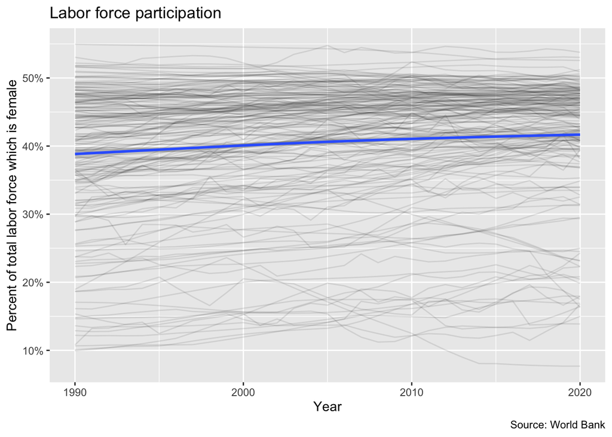

```r
ggplot(data = female_labor, mapping = aes(x = date, y = fem_lab_part)) +
  geom_line(mapping = aes(group = country), alpha = .1) +
  geom_smooth() +
  # documentation https://rdrr.io/cran/scales/man/percent_format.html
  scale_y_continuous(labels = scales::percent_format(scale = 1)) +
  labs(
    title = "Labor force participation",
    x = "Year",
    y = "Percent of total labor force which is female",
    caption = "Source: World Bank"
  )
```

By default, `wb_data()` returns queries as data frames in a wide format. So if we request multiple indicators, each indicator will be stored in its own column:

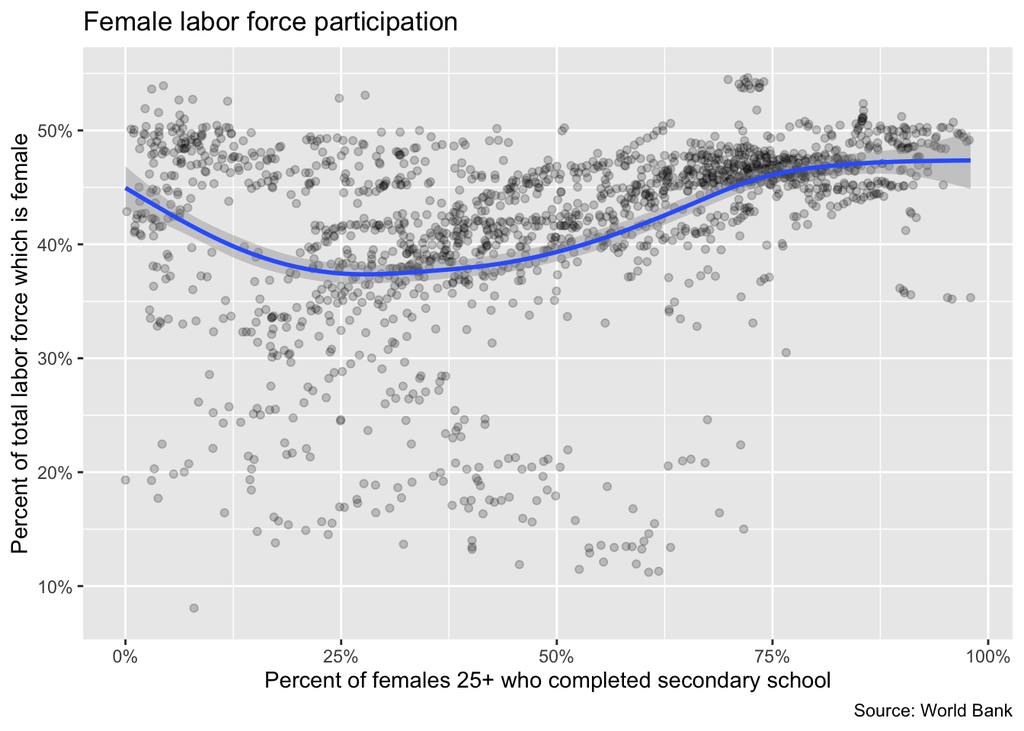

```r
female_vars <- wb_data(
  indicator = c(
    "fem_lab_part" = "SL.TLF.TOTL.FE.ZS",
    "fem_educ_sec" = "SE.SEC.CUAT.UP.FE.ZS"
  ),
  start_date = 1990,
  end_date = 2020
)

ggplot(data = female_vars, mapping = aes(x = fem_educ_sec, y = fem_lab_part)) +
  geom_point(alpha = .2) +
  geom_smooth() +
  scale_x_continuous(labels = scales::percent_format(scale = 1)) +
  scale_y_continuous(labels = scales::percent_format(scale = 1)) +
  labs(
    title = "Female labor force participation",
    x = "Percent of females 25+ who completed secondary school",
    y = "Percent of total labor force which is female",
    caption = "Source: World Bank"
  )
```

```r
write_csv(female_labor, "data/wb_female_labor.csv")
write_csv(female_vars, "data/wb_female_vars.csv")
```